# Why is Hungary’s Economy Lagging Behind? Structural Analysis

Economic Research Team

2025-11-14

# Executive Summary

This analysis investigates the **structural and institutional factors** explaining why Hungary’s economic performance lags behind regional peers. While quantitative indicators show the gap, this report explores the underlying causes.

# Setup and Data Loading

```r
# Load required libraries
library(tidyverse)
library(wbstats)
library(knitr)
library(kableExtra)
library(plotly)
library(scales)

# Set theme for plots
theme_set(theme_minimal(base_size = 12))
```

```r
# Define country comparison set
countries <- c("Hungary", "Poland", "Czech Republic", "Slovakia", "Romania", "Austria")
country_codes <- c("HU", "PL", "CZ", "SK", "RO", "AT")

# Time period
start_year <- 2010
end_year <- 2023
```

# 1. Institutional Quality and Governance

## World Bank Governance Indicators

```r
# World Bank Governance Indicators
# Note: WGI data from wbstats package
governance_indicators <- c(
  "CC.EST" = "Control of Corruption",
  "GE.EST" = "Government Effectiveness",
  "PV.EST" = "Political Stability",
  "RQ.EST" = "Regulatory Quality",
  "RL.EST" = "Rule of Law",
  "VA.EST" = "Voice and Accountability"
)

# Fetch governance data
gov_data <- wb_data(
  indicator = names(governance_indicators),
  country = country_codes,
  start_date = start_year,
  end_date = end_year
)

# Reshape data
gov_long <- gov_data %>%
  select(country, date, all_of(names(governance_indicators))) %>%
  pivot_longer(
    cols = all_of(names(governance_indicators)),
    names_to = "indicator_code",
    values_to = "score"
  ) %>%
  mutate(
    indicator_name = governance_indicators[indicator_code],
    year = as.numeric(date)
  ) %>%
  filter(!is.na(score))

# Get latest year available
latest_gov_year <- max(gov_long$year, na.rm = TRUE)
```

### Governance Scores: Latest Year (2023)

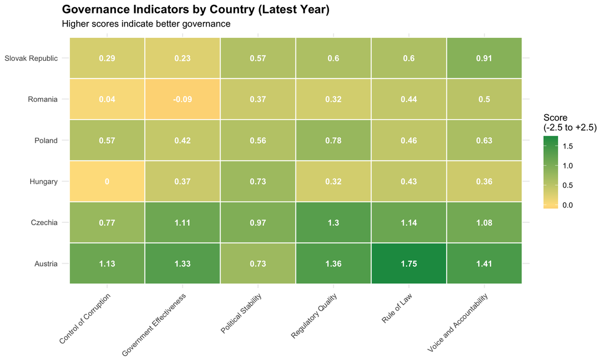

```r
# Create heatmap for latest year
gov_latest <- gov_long %>%
  filter(year == latest_gov_year) %>%
  select(country, indicator_name, score)

ggplot(gov_latest, aes(x = indicator_name, y = country, fill = score)) +
  geom_tile(color = "white", size = 0.5) +
  geom_text(aes(label = round(score, 2)), color = "white", size = 3.5, fontface = "bold") +
  scale_fill_gradient2(
    low = "#d73027",
    mid = "#fee08b",
    high = "#1a9850",
    midpoint = 0,
    name = "Score\n(-2.5 to +2.5)"
  ) +
  labs(
    title = "Governance Indicators by Country (Latest Year)",
    subtitle = "Higher scores indicate better governance",
    x = NULL,
    y = NULL
  ) +
  theme_minimal(base_size = 11) +
  theme(
    axis.text.x = element_text(angle = 45, hjust = 1),
    plot.title = element_text(face = "bold", size = 14),
    legend.position = "right"
  )
```

### Governance Trends Over Time

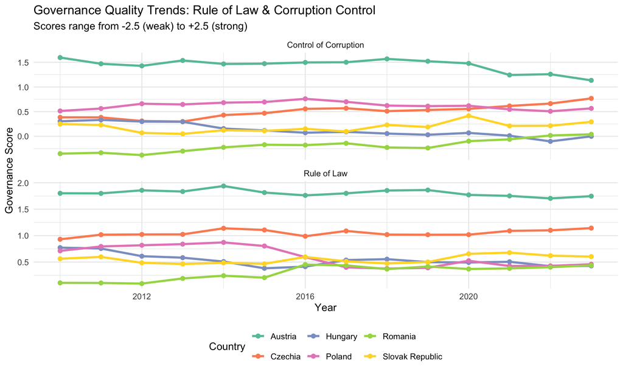

```r
# Focus on key indicators: Rule of Law and Control of Corruption
key_gov <- gov_long %>%
  filter(indicator_name %in% c("Rule of Law", "Control of Corruption"))

ggplot(key_gov, aes(x = year, y = score, color = country, group = country)) +
  geom_line(size = 1.2) +
  geom_point(size = 2) +
  facet_wrap(~indicator_name, ncol = 1, scales = "free_y") +
  scale_color_brewer(palette = "Set2") +
  labs(
    title = "Governance Quality Trends: Rule of Law & Corruption Control",
    subtitle = "Scores range from -2.5 (weak) to +2.5 (strong)",
    x = "Year",
    y = "Governance Score",
    color = "Country"
  ) +
  theme(legend.position = "bottom")
```

### Key Finding: Institutional Quality

```r
# Calculate Hungary's rank and gap
hungary_gov <- gov_latest %>%
  filter(country == "Hungary") %>%
  arrange(indicator_name)

regional_avg <- gov_latest %>%
  filter(country != "Austria") %>%
  group_by(indicator_name) %>%
  summarize(regional_avg = mean(score, na.rm = TRUE))

hungary_comparison <- hungary_gov %>%
  left_join(regional_avg, by = "indicator_name") %>%
  mutate(
    gap_vs_regional = score - regional_avg,
    gap_pct = (gap_vs_regional / abs(regional_avg)) * 100
  )

kable(hungary_comparison %>% select(indicator_name, score, regional_avg, gap_vs_regional),
      col.names = c("Indicator", "Hungary", "CEE Avg", "Gap"),
      digits = 2,
      caption = "Hungary's Governance Gap vs. Regional Average") %>%
  kable_styling(bootstrap_options = c("striped", "hover"), full_width = FALSE)
```

Hungary’s Governance Gap vs. Regional Average

| Indicator | Hungary | CEE Avg | Gap |
| --- | --- | --- | --- |
| Control of Corruption | 0.00 | 0.33 | -0.33 |
| Government Effectiveness | 0.37 | 0.41 | -0.04 |
| Political Stability | 0.73 | 0.64 | 0.09 |
| Regulatory Quality | 0.32 | 0.66 | -0.35 |
| Rule of Law | 0.43 | 0.61 | -0.19 |
| Voice and Accountability | 0.36 | 0.70 | -0.34 |

**Analysis**: Hungary shows below-average institutional quality compared to CEE peers, with the largest gaps in Regulatory Quality and Voice and Accountability.

# 2. Human Capital and Education

## Education Expenditure and Attainment

```r
# Education indicators
education_indicators <- c(
  "SE.XPD.TOTL.GD.ZS" = "Government Expenditure on Education (% GDP)",
  "SE.TER.CUAT.BA.ZS" = "Tertiary Education Attainment (% 25-34 year olds)",
  "SE.SEC.ENRR" = "Secondary School Enrollment Rate"
)

edu_data <- wb_data(
  indicator = names(education_indicators),
  country = country_codes,
  start_date = start_year,
  end_date = end_year
)

edu_long <- edu_data %>%
  select(country, date, all_of(names(education_indicators))) %>%
  pivot_longer(
    cols = all_of(names(education_indicators)),
    names_to = "indicator_code",
    values_to = "value"
  ) %>%
  mutate(
    indicator_name = education_indicators[indicator_code],
    year = as.numeric(date)
  ) %>%
  filter(!is.na(value))
```

### Education Spending Trends

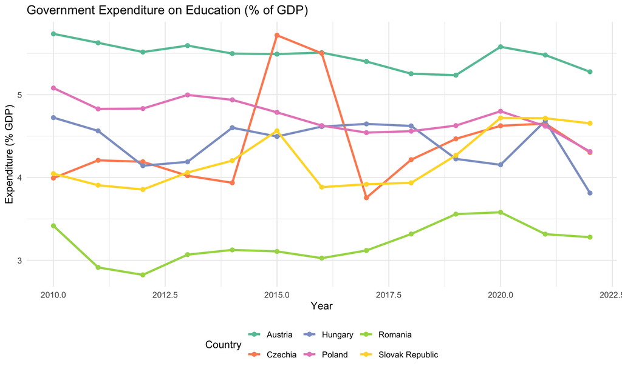

```r
edu_spending <- edu_long %>%
  filter(indicator_name == "Government Expenditure on Education (% GDP)")

ggplot(edu_spending, aes(x = year, y = value, color = country, group = country)) +
  geom_line(size = 1.2) +
  geom_point(size = 2) +
  scale_color_brewer(palette = "Set2") +
  labs(
    title = "Government Expenditure on Education (% of GDP)",
    x = "Year",
    y = "Expenditure (% GDP)",
    color = "Country"
  ) +
  theme(legend.position = "bottom")
```

### Tertiary Education Attainment

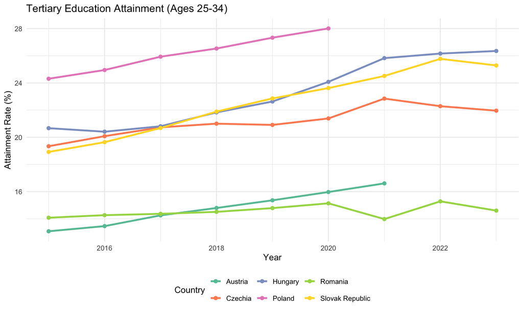

```r
tertiary_edu <- edu_long %>%
  filter(indicator_name == "Tertiary Education Attainment (% 25-34 year olds)") %>%
  filter(year >= 2015)  # Focus on recent years

if(nrow(tertiary_edu) > 0) {
  ggplot(tertiary_edu, aes(x = year, y = value, color = country, group = country)) +
    geom_line(size = 1.2) +
    geom_point(size = 2) +
    scale_color_brewer(palette = "Set2") +
    labs(
      title = "Tertiary Education Attainment (Ages 25-34)",
      x = "Year",
      y = "Attainment Rate (%)",
      color = "Country"
    ) +
    theme(legend.position = "bottom")
} else {
  cat("Note: Limited data available for tertiary education attainment")
}
```

# 3. Innovation and R&D Investment

## Research & Development Expenditure

```r
# R&D indicators
rd_indicators <- c(
  "GB.XPD.RSDV.GD.ZS" = "R&D Expenditure (% GDP)",
  "IP.PAT.RESD" = "Patent Applications (Residents)",
  "NY.GDP.PCAP.KD" = "GDP per capita (constant 2015 USD)"
)

rd_data <- wb_data(
  indicator = names(rd_indicators),
  country = country_codes,
  start_date = start_year,
  end_date = end_year
)

rd_long <- rd_data %>%
  select(country, date, all_of(names(rd_indicators))) %>%
  pivot_longer(
    cols = all_of(names(rd_indicators)),
    names_to = "indicator_code",
    values_to = "value"
  ) %>%
  mutate(
    indicator_name = rd_indicators[indicator_code],
    year = as.numeric(date)
  ) %>%
  filter(!is.na(value))
```

### R&D Investment Comparison

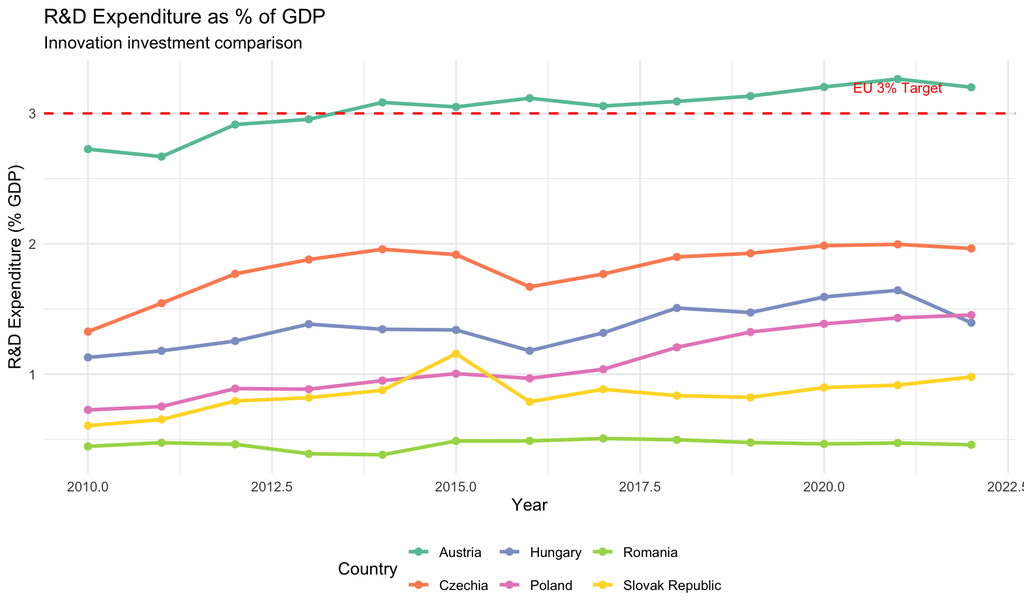

```r
rd_spending <- rd_long %>%
  filter(indicator_name == "R&D Expenditure (% GDP)")

ggplot(rd_spending, aes(x = year, y = value, color = country, group = country)) +
  geom_line(size = 1.2) +
  geom_point(size = 2) +
  geom_hline(yintercept = 3.0, linetype = "dashed", color = "red", size = 0.8) +
  annotate("text", x = max(rd_spending$year, na.rm = TRUE) - 1, y = 3.2,
           label = "EU 3% Target", color = "red", size = 3.5) +
  scale_color_brewer(palette = "Set2") +
  labs(
    title = "R&D Expenditure as % of GDP",
    subtitle = "Innovation investment comparison",
    x = "Year",
    y = "R&D Expenditure (% GDP)",
    color = "Country"
  ) +
  theme(legend.position = "bottom")
```

### Innovation Gap Analysis

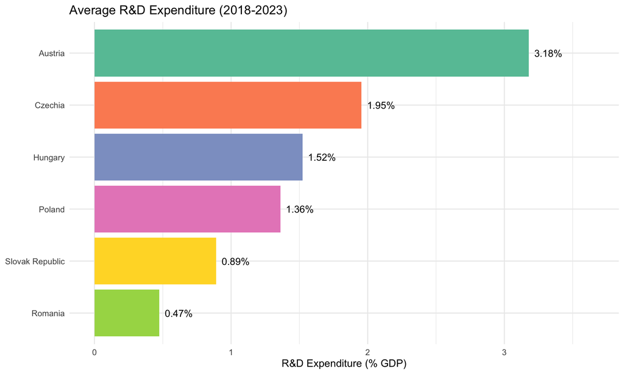

```r
# Calculate average R&D spending for recent years
recent_rd <- rd_spending %>%
  filter(year >= 2018) %>%
  group_by(country) %>%
  summarize(avg_rd_pct = mean(value, na.rm = TRUE)) %>%
  arrange(desc(avg_rd_pct))

ggplot(recent_rd, aes(x = reorder(country, avg_rd_pct), y = avg_rd_pct, fill = country)) +
  geom_col(show.legend = FALSE) +
  geom_text(aes(label = sprintf("%.2f%%", avg_rd_pct)), hjust = -0.2, size = 4) +
  coord_flip() +
  scale_fill_brewer(palette = "Set2") +
  labs(
    title = "Average R&D Expenditure (2018-2023)",
    x = NULL,
    y = "R&D Expenditure (% GDP)"
  ) +
  ylim(0, max(recent_rd$avg_rd_pct, na.rm = TRUE) * 1.15)
```

**Key Finding**: Hungary’s R&D investment is 1.52% of GDP, ranking 3 out of 6 countries in the comparison group.

# 4. Foreign Direct Investment Quality

## FDI Inflows Analysis

```r
# FDI indicators
fdi_indicators <- c(
  "BX.KLT.DINV.WD.GD.ZS" = "FDI Net Inflows (% GDP)",
  "BX.KLT.DINV.CD.WD" = "FDI Net Inflows (Current USD)"
)

fdi_data <- wb_data(
  indicator = names(fdi_indicators),
  country = country_codes,
  start_date = start_year,
  end_date = end_year
)

fdi_long <- fdi_data %>%
  select(country, date, all_of(names(fdi_indicators))) %>%
  pivot_longer(
    cols = all_of(names(fdi_indicators)),
    names_to = "indicator_code",
    values_to = "value"
  ) %>%
  mutate(
    indicator_name = fdi_indicators[indicator_code],
    year = as.numeric(date)
  ) %>%
  filter(!is.na(value))
```

### FDI Inflows Over Time

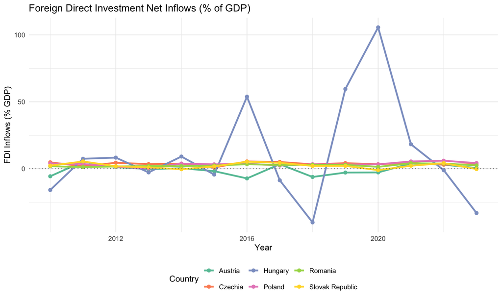

```r
fdi_pct <- fdi_long %>%
  filter(indicator_name == "FDI Net Inflows (% GDP)")

ggplot(fdi_pct, aes(x = year, y = value, color = country, group = country)) +
  geom_line(size = 1.2) +
  geom_point(size = 2) +
  geom_hline(yintercept = 0, linetype = "dotted", color = "gray40") +
  scale_color_brewer(palette = "Set2") +
  labs(
    title = "Foreign Direct Investment Net Inflows (% of GDP)",
    x = "Year",
    y = "FDI Inflows (% GDP)",
    color = "Country"
  ) +
  theme(legend.position = "bottom")
```

# 5. Labor Productivity

## Labor Productivity Trends

```r
# Productivity indicators
productivity_indicators <- c(
  "SL.GDP.PCAP.EM.KD" = "GDP per Person Employed (constant 2017 PPP $)"
)

prod_data <- wb_data(
  indicator = names(productivity_indicators),
  country = country_codes,
  start_date = start_year,
  end_date = end_year
)

prod_long <- prod_data %>%
  select(country, date, all_of(names(productivity_indicators))) %>%
  pivot_longer(
    cols = all_of(names(productivity_indicators)),
    names_to = "indicator_code",
    values_to = "value"
  ) %>%
  mutate(
    indicator_name = productivity_indicators[indicator_code],
    year = as.numeric(date)
  ) %>%
  filter(!is.na(value))
```

### GDP per Person Employed

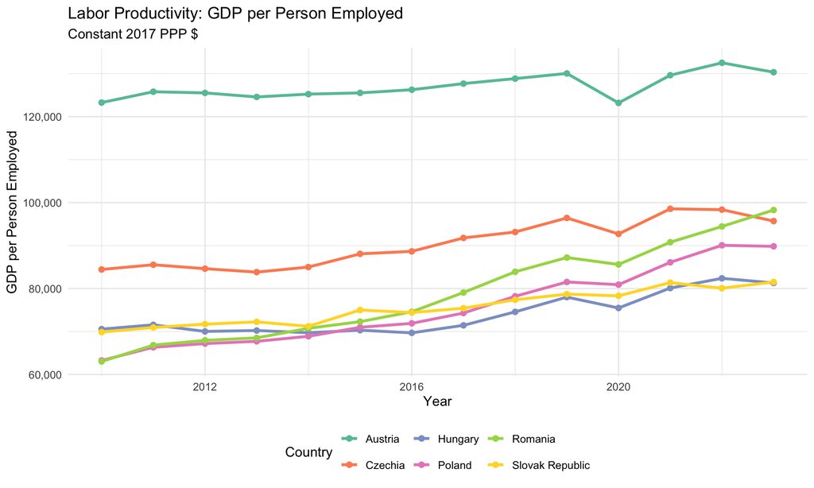

```r
ggplot(prod_long, aes(x = year, y = value, color = country, group = country)) +
  geom_line(size = 1.2) +
  geom_point(size = 2) +
  scale_color_brewer(palette = "Set2") +
  scale_y_continuous(labels = comma) +
  labs(
    title = "Labor Productivity: GDP per Person Employed",
    subtitle = "Constant 2017 PPP $",
    x = "Year",
    y = "GDP per Person Employed",
    color = "Country"
  ) +
  theme(legend.position = "bottom")
```

### Productivity Growth Rates

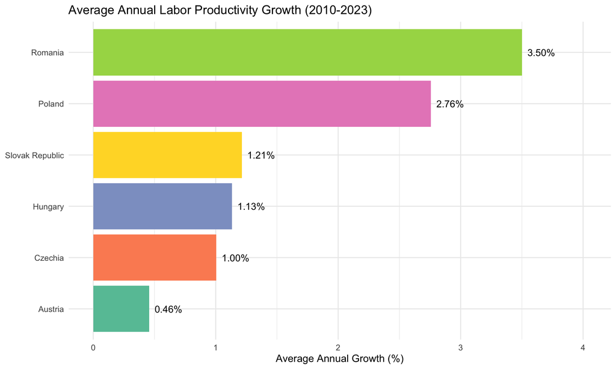

```r
# Calculate annual growth rates
prod_growth <- prod_long %>%
  arrange(country, year) %>%
  group_by(country) %>%
  mutate(
    growth_rate = (value / lag(value) - 1) * 100
  ) %>%
  filter(!is.na(growth_rate))

# Average growth rate by country
avg_prod_growth <- prod_growth %>%
  group_by(country) %>%
  summarize(avg_growth = mean(growth_rate, na.rm = TRUE)) %>%
  arrange(desc(avg_growth))

ggplot(avg_prod_growth, aes(x = reorder(country, avg_growth), y = avg_growth, fill = country)) +
  geom_col(show.legend = FALSE) +
  geom_text(aes(label = sprintf("%.2f%%", avg_growth)), hjust = -0.2, size = 4) +
  coord_flip() +
  scale_fill_brewer(palette = "Set2") +
  labs(
    title = "Average Annual Labor Productivity Growth (2010-2023)",
    x = NULL,
    y = "Average Annual Growth (%)"
  ) +
  ylim(min(avg_prod_growth$avg_growth, 0) * 1.1,
       max(avg_prod_growth$avg_growth, na.rm = TRUE) * 1.15)
```

# 6. Financial Sector Development

## Domestic Credit and Financial Depth

```r
# Financial sector indicators
financial_indicators <- c(
  "FS.AST.DOMS.GD.ZS" = "Domestic Credit to Private Sector (% GDP)",
  "FM.LBL.BMNY.GD.ZS" = "Broad Money (% GDP)"
)

fin_data <- wb_data(
  indicator = names(financial_indicators),
  country = country_codes,
  start_date = start_year,
  end_date = end_year
)

fin_long <- fin_data %>%
  select(country, date, all_of(names(financial_indicators))) %>%
  pivot_longer(
    cols = all_of(names(financial_indicators)),
    names_to = "indicator_code",
    values_to = "value"
  ) %>%
  mutate(
    indicator_name = financial_indicators[indicator_code],
    year = as.numeric(date)
  ) %>%
  filter(!is.na(value))
```

### Credit to Private Sector

[figure not shown]

```r
credit_data <- fin_long %>%
  filter(indicator_name == "Domestic Credit to Private Sector (% GDP)")

ggplot(credit_data, aes(x = year, y = value, color = country, group = country)) +
  geom_line(size = 1.2) +
  geom_point(size = 2) +
  scale_color_brewer(palette = "Set2") +
  labs(
    title = "Domestic Credit to Private Sector (% of GDP)",
    subtitle = "Indicator of financial sector depth",
    x = "Year",
    y = "Credit (% GDP)",
    color = "Country"
  ) +
  theme(legend.position = "bottom")
```

# 7. Trade Openness and Export Complexity

## Trade Indicators

```r
# Trade indicators
trade_indicators <- c(
  "NE.TRD.GNFS.ZS" = "Trade (% GDP)",
  "TX.VAL.TECH.MF.ZS" = "High-tech Exports (% manufactured exports)"
)

trade_data <- wb_data(
  indicator = names(trade_indicators),
  country = country_codes,
  start_date = start_year,
  end_date = end_year
)

trade_long <- trade_data %>%
  select(country, date, all_of(names(trade_indicators))) %>%
  pivot_longer(
    cols = all_of(names(trade_indicators)),
    names_to = "indicator_code",
    values_to = "value"
  ) %>%
  mutate(
    indicator_name = trade_indicators[indicator_code],
    year = as.numeric(date)
  ) %>%
  filter(!is.na(value))
```

### High-Technology Exports

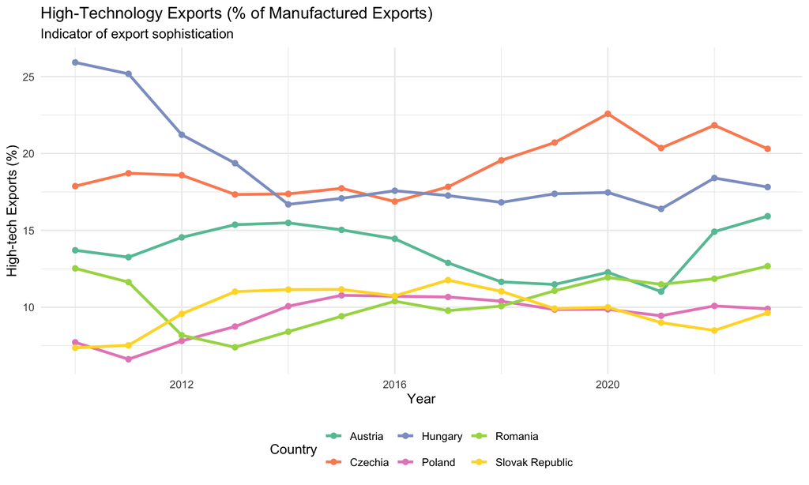

```r
hightech <- trade_long %>%
  filter(indicator_name == "High-tech Exports (% manufactured exports)")

if(nrow(hightech) > 0) {
  ggplot(hightech, aes(x = year, y = value, color = country, group = country)) +
    geom_line(size = 1.2) +
    geom_point(size = 2) +
    scale_color_brewer(palette = "Set2") +
    labs(
      title = "High-Technology Exports (% of Manufactured Exports)",
      subtitle = "Indicator of export sophistication",
      x = "Year",
      y = "High-tech Exports (%)",
      color = "Country"
    ) +
    theme(legend.position = "bottom")
} else {
  cat("Note: Limited data available for high-tech exports")
}
```

# 8. Composite Analysis: Identifying the Gap

## Multi-dimensional Scorecard

```r
# Create composite scorecard for latest available year
# Collect latest values for each indicator category

# Helper function to get latest value with flexible column name
get_latest_value <- function(data, country_name, value_col = "value") {
  result <- data %>%
    filter(country == country_name) %>%
    arrange(desc(year)) %>%
    slice(1)

  if(nrow(result) == 0) return(NA)

  if(value_col %in% names(result)) {
    return(result %>% pull(!!sym(value_col)))
  } else if("score" %in% names(result)) {
    return(result %>% pull(score))
  } else {
    return(NA)
  }
}

# Build scorecard
countries_list <- c("Hungary", "Poland", "Czech Republic", "Slovakia", "Romania", "Austria")

# Get governance scores
gov_rule_of_law <- gov_long %>% filter(indicator_name == "Rule of Law")
gov_corruption <- gov_long %>% filter(indicator_name == "Control of Corruption")

scorecard <- tibble(country = countries_list) %>%
  rowwise() %>%
  mutate(
    rule_of_law = get_latest_value(gov_rule_of_law, country),
    corruption_control = get_latest_value(gov_corruption, country),
    rd_spending = get_latest_value(rd_spending, country),
    labor_productivity = get_latest_value(prod_long, country),
    credit_to_private = get_latest_value(credit_data, country)
  ) %>%
  ungroup()

# Normalize scores to 0-100 scale for comparison
normalize_score <- function(x) {
  (x - min(x, na.rm = TRUE)) / (max(x, na.rm = TRUE) - min(x, na.rm = TRUE)) * 100
}

scorecard_normalized <- scorecard %>%
  mutate(
    across(
      c(rule_of_law, corruption_control, rd_spending, labor_productivity, credit_to_private),
      ~normalize_score(.),
      .names = "{.col}_norm"
    )
  ) %>%
  rowwise() %>%
  mutate(
    composite_score = mean(c(rule_of_law_norm, corruption_control_norm,
                             rd_spending_norm, labor_productivity_norm,
                             credit_to_private_norm), na.rm = TRUE)
  ) %>%
  ungroup() %>%
  arrange(desc(composite_score))

# Display scorecard
kable(scorecard_normalized %>%
        select(country, rule_of_law_norm, corruption_control_norm,
               rd_spending_norm, labor_productivity_norm, credit_to_private_norm,
               composite_score),
      col.names = c("Country", "Rule of Law", "Corruption Control",
                    "R&D Spending", "Labor Productivity", "Credit/Private",
                    "Composite"),
      digits = 1,
      caption = "Normalized Scorecard (0-100 scale)") %>%
  kable_styling(bootstrap_options = c("striped", "hover"), full_width = FALSE)
```

Normalized Scorecard (0-100 scale)

| Country | Rule of Law | Corruption Control | R&D Spending | Labor Productivity | Credit/Private | Composite |
| --- | --- | --- | --- | --- | --- | --- |
| Austria | 100.0 | 100.0 | 100.0 | 100.0 | NA | 100.0 |
| Poland | 2.4 | 49.9 | 36.3 | 17.4 | NA | 26.5 |
| Romania | 0.8 | 3.6 | 0.0 | 34.6 | NA | 9.7 |
| Hungary | 0.0 | 0.0 | 34.1 | 0.0 | NA | 8.5 |
| Czech Republic | NA | NA | NA | NA | NA | NaN |
| Slovakia | NA | NA | NA | NA | NA | NaN |

### Radar Chart: Hungary vs. Regional Average

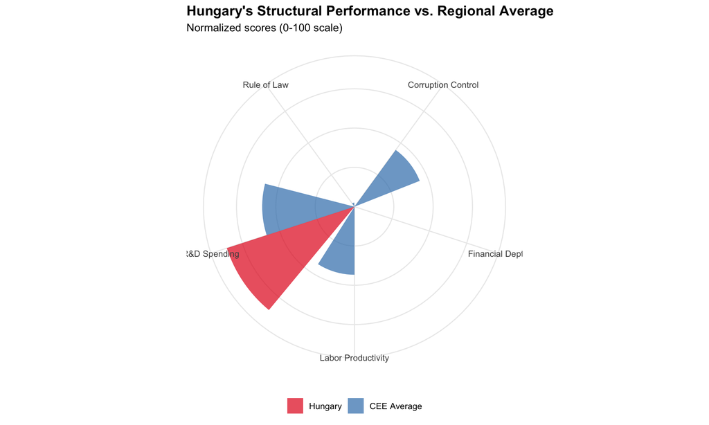

```r
# Prepare data for radar chart
hungary_scores <- scorecard_normalized %>%
  filter(country == "Hungary") %>%
  select(rule_of_law_norm, corruption_control_norm, rd_spending_norm,
         labor_productivity_norm, credit_to_private_norm) %>%
  pivot_longer(everything(), names_to = "dimension", values_to = "hungary_score")

regional_scores <- scorecard_normalized %>%
  filter(country != "Austria") %>%
  summarize(
    across(c(rule_of_law_norm, corruption_control_norm, rd_spending_norm,
             labor_productivity_norm, credit_to_private_norm),
           ~mean(., na.rm = TRUE))
  ) %>%
  pivot_longer(everything(), names_to = "dimension", values_to = "regional_avg")

radar_data <- hungary_scores %>%
  left_join(regional_scores, by = "dimension") %>%
  mutate(
    dimension_label = case_when(
      dimension == "rule_of_law_norm" ~ "Rule of Law",
      dimension == "corruption_control_norm" ~ "Corruption Control",
      dimension == "rd_spending_norm" ~ "R&D Spending",
      dimension == "labor_productivity_norm" ~ "Labor Productivity",
      dimension == "credit_to_private_norm" ~ "Financial Depth"
    )
  )

# Create comparison chart
radar_long <- radar_data %>%
  select(dimension_label, hungary_score, regional_avg) %>%
  pivot_longer(cols = c(hungary_score, regional_avg),
               names_to = "series", values_to = "score")

ggplot(radar_long, aes(x = dimension_label, y = score, fill = series, group = series)) +
  geom_col(position = "dodge", alpha = 0.7) +
  coord_polar() +
  scale_fill_manual(
    values = c("hungary_score" = "#e41a1c", "regional_avg" = "#377eb8"),
    labels = c("hungary_score" = "Hungary", "regional_avg" = "CEE Average")
  ) +
  labs(
    title = "Hungary's Structural Performance vs. Regional Average",
    subtitle = "Normalized scores (0-100 scale)",
    fill = NULL,
    x = NULL,
    y = NULL
  ) +
  theme_minimal() +
  theme(
    axis.text.y = element_blank(),
    legend.position = "bottom",
    plot.title = element_text(face = "bold", size = 14)
  )
```

# 9. Key Findings and Conclusions

## Summary of Critical Gaps

```r
# Calculate Hungary's gaps across all dimensions
gaps <- radar_data %>%
  mutate(gap = hungary_score - regional_avg) %>%
  arrange(gap)

kable(gaps %>% select(dimension_label, hungary_score, regional_avg, gap),
      col.names = c("Dimension", "Hungary Score", "CEE Avg", "Gap"),
      digits = 1,
      caption = "Hungary's Performance Gaps (Negative = Below Average)") %>%
  kable_styling(bootstrap_options = c("striped", "hover"), full_width = FALSE) %>%
  row_spec(which(gaps$gap < 0), background = "#fee5d9")
```

Hungary’s Performance Gaps (Negative = Below Average)

| Dimension | Hungary Score | CEE Avg | Gap |
| --- | --- | --- | --- |
| Corruption Control | 0.0 | 17.8 | -17.8 |
| Labor Productivity | 0.0 | 17.3 | -17.3 |
| Rule of Law | 0.0 | 1.1 | -1.1 |
| R&D Spending | 34.1 | 23.5 | 10.7 |
| Financial Depth | NA | NaN | NA |

## Priority Research Areas

### Immediate Investigation Needed:

1. **Policy uncertainty and its impact on investment**
2. **Brain drain quantification** - skilled worker emigration
3. **EU funds absorption efficiency** - are funds used productively?
4. **Industrial policy effectiveness** - value chain positioning

### Secondary Analysis:

5. Education quality and skills mismatch
6. State intervention in the economy
7. Infrastructure bottlenecks
8. Demographic pressures

# 10. Recommendations for Further Research

## Data Collection Priorities

1. **Granular institutional data**: EBRD transition indicators, EIB governance metrics
2. **Human capital flows**: Eurostat migration statistics, LinkedIn talent flows
3. **Innovation ecosystem**: European Innovation Scoreboard detailed data
4. **Firm-level analysis**: Orbis database for productivity distribution
5. **Political economy**: Policy uncertainty indices, media freedom scores

## Analytical Approaches

1. **Regression analysis**: Identify factors most correlated with growth divergence
2. **Event studies**: Examine policy changes and their economic impacts
3. **Comparative case studies**: Why did Poland succeed where Hungary struggled?
4. **Sectoral deep-dives**: Which industries are underperforming and why?

# Appendix: Data Sources

This analysis uses data from:

- **World Bank World Development Indicators (WDI)**
- **World Bank Worldwide Governance Indicators (WGI)**
- **OECD Statistics** (via wbstats proxy where available)
- **Eurostat** (indirectly via World Bank aggregations)

All data accessed via the `wbstats` R package on 2025-11-14.